# Tutorial de muestreo en R

#### Ejemplo con diseño complejo real

Finalmente, se desarrollará un ejemplo con un diseño complejo real,utilizando la ENAHO 2012.

El diseño muestral se detalla a continuación:

**Diseño muestral:** diseño probabilístico, estratificado y bietápico. En la primera etapa se seleccionaron segmentos censales o unidades primarias de muestreo (UPM) con probabilidad proporcional al tamaño (PPT), y en la segunda etapa se seleccionaron las viviendas o unidades secundarias de muestreo (USM) con probabilidades iguales de selección dentro de cada segmento, mediante muestreo sistemático con arranque aleatorio.

**Dominios de estudio:** las seis regiones de planificación y las zonas urbana y rural.

```r
#Objetos para generar variables(debido a que el Dataframe de ENAHO2012 tiene las labels del SPSS y no los valores)

profesionales<- c("Profesionales científicos e intelectuales")
tecnicos<- c("Técnicos y profesionales de nivel medio")

#Generando df de ENAHO2012 a nivel de hogar

df12<- ENAHO2012 %.%  #Define nuevo data frame
  mutate(pobre=ifelse(np=="No pobre",0,1), #Crea variable de pobreza.
         Profesional=ifelse(OcupFuerzaTrab==profesionales,1,0), #Crea flag de Profesional.
         Tecnico=ifelse(OcupFuerzaTrab==tecnicos,1,0)) %.%  #Crea flag de tecnico.
  select(FACTOR:ZONA,pobre,Profesional,Tecnico,ipcn) %.% #Selecciona variables de interés.
  group_by(SEGMENTO,CUESTIONARIO,HOGAR,ZONA,REGION) %.% #Genera esquema de agrupación.
  summarise(Factor=mean(FACTOR),
            pobre=mean(pobre),
            Profesionales=sum(Profesional),
            Tecnicos=sum(Tecnico),
            Ingreso=mean(ipcn)) %.%
  mutate(id=paste0(SEGMENTO,CUESTIONARIO,HOGAR,ZONA,REGION)) #Genera id único para uso posterior.

#Establecer el diseño muestral

design2<-svydesign(data=df12,id=~SEGMENTO+id,
                   strata=~REGION+ZONA,pps="brewer",weights=~Factor)

summary(design2)
```

```r
## Stratified 2 - level Cluster Sampling design (with replacement)
## With (1120, 11374) clusters.
## svydesign(data = df12, id = ~SEGMENTO + id, strata = ~REGION +
##     ZONA, pps = "brewer", weights = ~Factor)
## Probabilities:
##     Min.  1st Qu.   Median     Mean  3rd Qu.     Max.
## 0.001403 0.008065 0.015380 0.016030 0.021280 0.062500
## First-level Stratum Sizes:
##            Central Chorotega Pacífico Central Brunca Huetar Atlántica
## obs           4940      1220             1144   1598             1218
## design.PSU     468       116              124    160              128
## actual.PSU     468       116              124    160              128
##            Huetar Norte
## obs                1254
## design.PSU          124
## actual.PSU          124
## Data variables:
##  [1] "SEGMENTO"      "CUESTIONARIO"  "HOGAR"         "ZONA"
##  [5] "REGION"        "Factor"        "pobre"         "Profesionales"
##  [9] "Tecnicos"      "Ingreso"       "id"
```

```r
#Calculando estadísticos de Pobreza por hogar nacionales

#Porcentaje de pobreza
pobremc<- svymean(~pobre,design=design2,deff=TRUE,na.rm=TRUE)

#Media de pobreza
pobremc
```

```r
##            mean        SE  DEff
## pobre 0.2067336 0.0063786 2.836
```

```r
#Efecto del diseño
deff(pobremc)
```

```r
##    pobre
## 2.835952
```

```r
#Intervalo de confianza
confint(pobremc)
```

```r
##           2.5 %    97.5 %
## pobre 0.1942318 0.2192355
```

```r
#Coeficiente de variación
cv(pobremc)
```

```r
##           pobre
## pobre 0.0308542
```

```r
#Total de pobres
pobretmc<-svytotal(~pobre,design=design2, deff=TRUE,na.rm=TRUE)

pobretmc
```

```r
##        total     SE   DEff
## pobre 279514  10334 4.0715
```

```r
#Efecto del diseño
deff(pobretmc)
```

```r
##    pobre
## 4.071516
```

```r
#Intervalo de confianza
confint(pobretmc)
```

```r
##          2.5 %   97.5 %
## pobre 259260.8 299767.2
```

```r
#Coeficiente de variación
cv(pobretmc)
```

```r
##            pobre
## pobre 0.03696945
```

```r
#Estimación de quantiles(Ingreso per cápita)
ingresoq<- svyquantile(~Ingreso,quantile= seq(0.2,1,0.2),design=design2, deff=TRUE,na.rm=TRUE)

ingresoq
```

```r
##             0.2      0.4      0.6    0.8        1
## Ingreso 85889.4 149602.9 245042.2 433385 13059042
```

```r
#Cálculo de razón(Profesionales/Técnicos)
ptratio<- svyratio(~Profesionales, ~Tecnicos, design=design2, deff=TRUE,na.rm=TRUE)

ptratio
```

```r
## Ratio estimator: svyratio.survey.design2(~Profesionales, ~Tecnicos, design = design2,
##     deff = TRUE, na.rm = TRUE)
## Ratios=
##               Tecnicos
## Profesionales 1.257501
## SEs=
##                Tecnicos
## Profesionales 0.1431679
```

```r
#Efecto del diseño
deff(ptratio)
```

```r
## [1] 2.278801
```

```r
#Intervalo de confianza
confint(ptratio)
```

```r
##                            2.5 %   97.5 %
## Profesionales/Tecnicos 0.9768973 1.538105
```

```r
#Coeficiente de variación
cv(ptratio)
```

```r
##                Tecnicos
## Profesionales 0.1138511
```

```r
#Estimaciones por estrato(Zona)

pobremZ<-svyby(~pobre, ~ZONA, design2, svymean,deff=TRUE,na.rm=TRUE)

#Media de pobreza por zona
pobremZ
```

```r
##          ZONA     pobre          se DEff.pobre
## Urbana Urbana 0.1834762 0.008193071   2.200074
## Rural   Rural 0.2714831 0.007898585   2.071340
```

```r
#Efecto del diseño
deff(pobremZ)
```

```r
## [1] 2.200074 2.071340
```

```r
#Intervalo de confianza
confint(pobremZ)
```

```r
##            2.5 %    97.5 %
## Urbana 0.1674180 0.1995343
## Rural  0.2560022 0.2869640
```

```r
#Coeficiente de variación
cv(pobremZ)
```

```r
##     Urbana      Rural
## 0.04465469 0.02909420
```

```r
#Estimaciones por estrato(Región)

pobremR<-svyby(~pobre,~REGION, design2, svymean,deff=TRUE,na.rm=TRUE)

#Media de pobreza por zona
pobremR
```

```r
##                            REGION     pobre          se DEff.pobre
## Central                   Central 0.1613506 0.008443248   2.602328
## Chorotega               Chorotega 0.3356425 0.018022067   1.795762
## Pacífico Central Pacífico Central 0.2688588 0.022885659   3.090166
## Brunca                     Brunca 0.3332134 0.021407389   3.339586
## Huetar Atlántica Huetar Atlántica 0.2480790 0.020845431   2.861739
## Huetar Norte         Huetar Norte 0.2320398 0.017439694   2.156538
```

```r
#Efecto del diseño
deff(pobremR)
```

```r
## [1] 2.602328 1.795762 3.090166 3.339586 2.861739 2.156538
```

```r
#Intervalo de confianza
confint(pobremR)
```

```r
##                      2.5 %    97.5 %
## Central          0.1448021 0.1778990
## Chorotega        0.3003199 0.3709651
## Pacífico Central 0.2240038 0.3137139
## Brunca           0.2912557 0.3751712
## Huetar Atlántica 0.2072227 0.2889353
## Huetar Norte     0.1978586 0.2662210
```

```r
#Coeficiente de variación
cv(pobremR)
```

```r
##          Central        Chorotega Pacífico Central           Brunca
##       0.05232859       0.05369424       0.08512146       0.06424527
## Huetar Atlántica     Huetar Norte
##       0.08402738       0.07515820
```

```r
#Estimaciones combinadas

pobremZR<-svyby(~pobre,~REGION+ZONA, design2, svymean,deff=TRUE,na.rm=TRUE)
```

**Costa Rica:Estimaciones de pobreza por estrato**

| Región | Zona | % Pobreza | SE | DEFF |
| --- | --- | --- | --- | --- |
| Central | Urbana | 15.80 | 0.96 | 1.80 |
| Chorotega | Urbana | 31.03 | 2.43 | 1.66 |
| Pacífico Central | Urbana | 27.58 | 3.20 | 2.26 |
| Brunca | Urbana | 27.95 | 4.03 | 3.21 |
| Huetar Atlántica | Urbana | 22.27 | 3.34 | 1.92 |
| Huetar Norte | Urbana | 18.05 | 2.15 | 1.81 |
| Central | Rural | 18.34 | 0.95 | 1.44 |
| Chorotega | Rural | 36.56 | 2.62 | 1.86 |
| Pacífico Central | Rural | 25.54 | 2.62 | 2.61 |
| Brunca | Rural | 37.56 | 1.97 | 2.02 |
| Huetar Atlántica | Rural | 28.35 | 1.68 | 1.31 |
| Huetar Norte | Rural | 26.00 | 2.34 | 1.95 |
| Fuente:ENAHO 2012,INEC |  |  |  |  |

#### Comparativa de las estimaciones publicadas y estimadas en el ejercicio

Para comparar la calidad de las estimaciones, se realizará una comparación entre la medición puntual de % de hogares pobres por Región.[Acá(página 68 del documento)](https://www.dropbox.com/s/psqdvbt8r4nwcja/Resultados%20Generales%20ENAHO-2012.pdf?dl=0) se encuentra el resultado oficial.

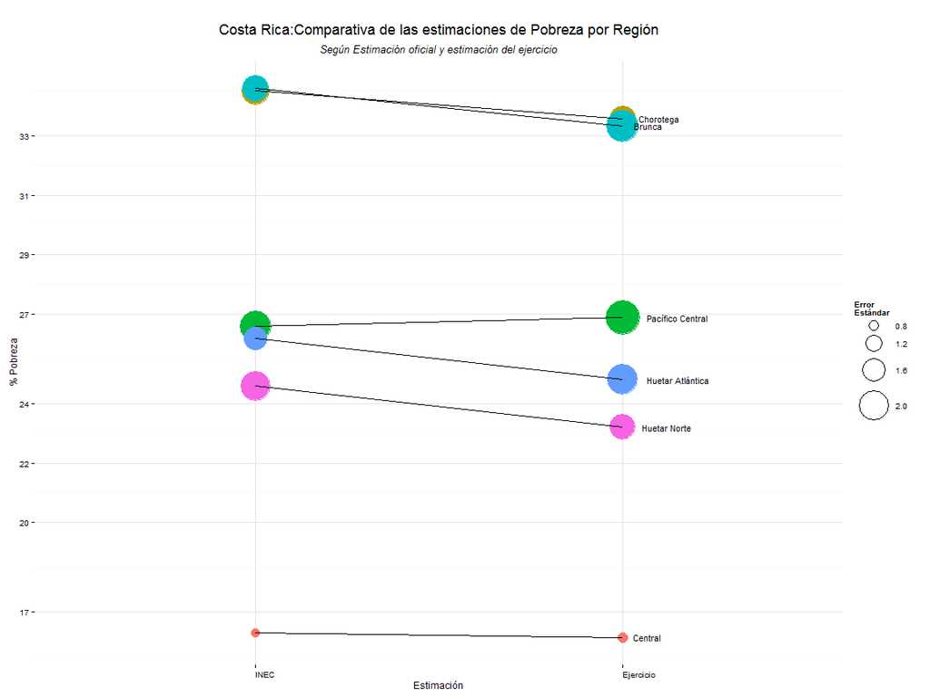

## Resumen de las funciones más relevantes utilizadas

[output not shown]

## Sesión de R

```r
## R version 3.1.1 (2014-07-10)
## Platform: x86_64-w64-mingw32/x64 (64-bit)
##
## locale:
## [1] LC_COLLATE=Spanish_Spain.1252  LC_CTYPE=Spanish_Spain.1252
## [3] LC_MONETARY=Spanish_Spain.1252 LC_NUMERIC=C
## [5] LC_TIME=Spanish_Spain.1252
##
## attached base packages:
## [1] grid      stats     graphics  grDevices utils     datasets  methods
## [8] base
##
## other attached packages:
## [1] ggplot2_1.0.0      tidyr_0.1          stargazer_5.1
## [4] survey_3.30-3      pps_0.94           DescTools_0.99.8.1
## [7] SamplingUtil_0.1   dplyr_0.2
##
## loaded via a namespace (and not attached):
##  [1] assertthat_0.1       boot_1.3-11          colorspace_1.2-4
##  [4] digest_0.6.4         evaluate_0.5.5       formatR_0.10
##  [7] gtable_0.1.2         htmltools_0.2.6      knitr_1.6.14
## [10] knitrBootstrap_1.0.0 labeling_0.2         markdown_0.7.4
## [13] MASS_7.3-33          mime_0.2             munsell_0.4.2
## [16] parallel_3.1.1       plyr_1.8.1           proto_0.3-10
## [19] Rcpp_0.11.2          reshape2_1.4         rmarkdown_0.3.3
## [22] scales_0.2.4         stringr_0.6.2        tcltk_3.1.1
## [25] tools_3.1.1          yaml_2.1.13
```

## Referencias

[1] T. Lumley. *Complex Surveys*. John Wiley & Sons, Inc., NA. DOI: 10.1002/9780470580066. .

Styled with knitrBootstrap